# Ley de Zif en biblia Arabe

Angel Garcia Baez

2023-03-16

# Cargando el archivo desde **XML**

Se tiene un documento en formato **XML** que contiene toda la biblia pero en lenguaje Arabe, la primera dificultad que se nos presenta es buscar la manera de extraer el texto del archivo en formato **XML**, para ello se hara uso de paqueterias dedicadas al manejo de este formato.

```r
# Cargamos las librerias necesarias
library(xml2)
library(XML)
library(tidyverse)
# Cargamos la ruta
ruta = "C:\\Users\\Angel\\Desktop\\MINERIA TEXTOS\\Ley de Zif\\ARABES.xml"

# Usamos la función read_xml para cargar el archivo XML
documento = read_xml(ruta)

# Usamos xmlParse para observar la estructura del XML
# y seleccionar la etiqueta que nos interesa

#xmlParse(documento)
```

## Para extraer la información del archivo

Con la finalidad de obtener todo el texto contenido en el archivo se recurre a localizar la etiquta que contiene todo el contenido de tipo texto para poder hacer una especie de consulta al XML y que nos extraiga todo el texto en un nuevo objeto.

```r
# Anidamos las funciones de "xml_find_all" para buscar todos los nodos
# y la función "xml_text" para que extraiga todo el texto de los nodos
#de le etiqueta "seg".

parrafos <- documento %>%
  xml_find_all(".//seg") %>%
  xml_text()
# Guardamos en el objeto T1
T1 = as.data.frame(parrafos)
dim(T1)
```

```
## [1] 31102     1
```

```r
# Mostramos los primeros 5 parrafos
head(T1$parrafos)
```

```
## [1] "\n\t\t\t\t\t\tفي البدء خلق الله السموات والارض.\n\t\t\t\t\t"
## [2] "\n\t\t\t\t\t\tوكانت الارض خربة وخالية وعلى وجه الغمر ظلمة وروح الله يرف على وجه المياه.\n\t\t\t\t\t"
## [3] "\n\t\t\t\t\t\tوقال الله ليكن نور فكان نور.\n\t\t\t\t\t"
## [4] "\n\t\t\t\t\t\tوراى الله النور انه حسن. وفصل الله بين النور والظلمة.\n\t\t\t\t\t"
## [5] "\n\t\t\t\t\t\tودعا الله النور نهارا والظلمة دعاها ليلا. وكان مساء وكان صباح يوما واحدا\n\t\t\t\t\t"
## [6] "\n\t\t\t\t\t\tوقال الله ليكن جلد في وسط المياه. وليكن فاصلا بين مياه ومياه.\n\t\t\t\t\t"
```

Notese que despues de la extracción del texto este mismo presenta tabuladores a la izquierda y a la derecha para centrarlo, esto no es de utilidad para poder hacer el conteo de las palabras, asi que se eliminan con el siguiente ciclo

```r
T1 = as.data.frame(parrafos)
# Limpiamos el espaciado de los parrafos
for(i in 1:nrow(T1)){
  # De la parte izquierda
  T1$parrafos[i]=str_replace(T1$parrafos[i],
                             "\n\t\t\t\t\t\t","")
  # De la parte derecha
  T1$parrafos[i]=str_replace(T1$parrafos[i],
                             "\n\t\t\t\t\t","")
}
# Mostramos el texto sin los tabuladores
# Mostramos los primeros 5 parrafos sin los tabuladores
head(T1$parrafos)
```

```
## [1] "في البدء خلق الله السموات والارض."
## [2] "وكانت الارض خربة وخالية وعلى وجه الغمر ظلمة وروح الله يرف على وجه المياه."
## [3] "وقال الله ليكن نور فكان نور."
## [4] "وراى الله النور انه حسن. وفصل الله بين النور والظلمة."
## [5] "ودعا الله النور نهارا والظلمة دعاها ليلا. وكان مساء وكان صباح يوما واحدا"
## [6] "وقال الله ليكن جلد في وسط المياه. وليكن فاصلا بين مياه ومياه."
```

```r
# Escribimos el archivo en un txt
#write.table(T1,"arabe.txt",row.names = F )
```

Se aprecia que dentro de las salidas el texto presenta tabulados a la izquierda y a la derecha con la finalidad de tener el texto centrado, pero esto no nos sirve, por lo que una vez extraído el texto en un objeto manipularle, ahora es momento de limpiarlo.

# Limpieza del texto y vectorizado

Consideraciones:

- El lenguaje árabe **NO** tiene mayúsculas ni minúsculas.

```r
# Librerias necesarias para la limpieza del texto
library(tm)
library(stringr)
#Elimar espacios al principio y al final
T1$parrafos <- gsub("^ ", "", T1$parrafos)
T1$parrafos <- gsub(" $", "", T1$parrafos)
#espacios vacios
T1$parrafos <- stripWhitespace(T1$parrafos)
# Vectorizado de la matriz (elaboración del corpus)
#ELABORACION DEL CORPUS
corpus <- Corpus(VectorSource(T1$parrafos))
MT = DocumentTermMatrix(corpus)
MT = as.matrix(MT)
# Muestro las primeras 10 palabras de los primeros 10 documentos
MT[1:10,1:10]
```

```
##    البدء السموات الله خلق في والارض. الارض الغمر المياه. خربة
## 1      1       1    1   1  1       1     0     0       0    0
## 2      0       0    1   0  0       0     1     1       1    1
## 3      0       0    1   0  0       0     0     0       0    0
## 4      0       0    2   0  0       0     0     0       0    0
## 5      0       0    1   0  0       0     0     0       0    0
## 6      0       0    1   0  1       0     0     0       1    0
## 7      0       0    1   0  0       0     0     0       0    0
## 8      0       0    1   0  0       0     0     0       0    0
## 9      0       0    1   0  0       0     0     0       0    0
## 10     0       0    2   0  0       0     0     0       0    0
```

# Conteo y ordenamiento de la matriz

Una vez que se logró obtener la matriz de términos (después de 3 minutos y 15 gb’s de memoria ram consumida) se procede a obtener los conteos por palabra y a ordenarlas de mayor a menor.

```r
# Obtengo la suma por palabra
totales = apply(MT, 2,sum)
Totales = sort(totales,decreasing = T)
# Nueva matriz final
Final = cbind.data.frame(Totales,names(Totales))
names(Final)  = c("Totales","Palabra")
# Escribir el archivo
write.table(Final,"ordenadas.txt")
# Las top 10 palabras
muestra = Final[1:10,]
muestra
```

```
##    Totales Palabra
## 1    10465      في
## 2    10064      من
## 3     6507     الى
## 4     5050    الرب
## 5     4275     على
## 6     4154      ان
## 7     3694      كل
## 8     3451      لا
## 9     2910    الذي
## 10    2284      قد
```

# Comprobando la ley de Ziff

En primera instancia se muestra en la siguiente tabla cada palabra con su respectiva traducción para revisar si las palabras que aparecen en el top son nombres, verbos o conectores.

```r
# Vector con las traducciones
traducciones = c("en","de","a mi",
  "Dios","sobre mí",
  "eso", "todo","No",
  "eso","tal vez")
# Proyectando la tabla con las traducciones
cbind.data.frame(Final[1:10,],traducciones)
```

```
##    Totales Palabra traducciones
## 1    10465      في           en
## 2    10064      من           de
## 3     6507     الى         a mi
## 4     5050    الرب         Dios
## 5     4275     على     sobre mí
## 6     4154      ان          eso
## 7     3694      كل         todo
## 8     3451      لا           No
## 9     2910    الذي          eso
## 10    2284      قد      tal vez
```

Se confirma que en el top se tienen en su mayoria conectores.

# Gráfico de las 10 palabras mas frecuentes

Se gráfican los resultados obtenidos del conteo de las palabras.

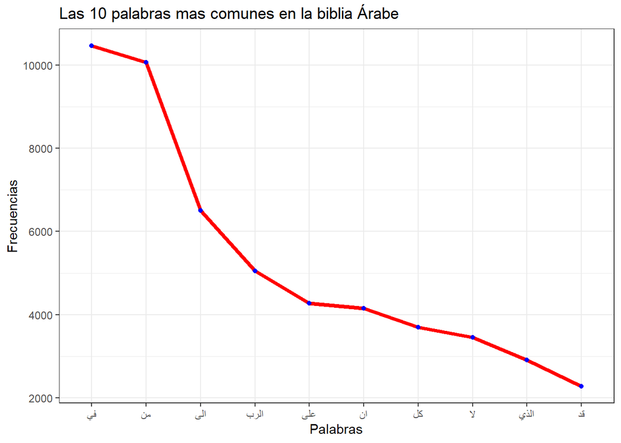

```r
library(ggplot2)
# Las top 10 palabras
muestra = Final[1:10,]
### Proyectar bonito los gráficos
ggplot(muestra,aes(x=reorder(Palabra,-Totales),
                   y = Totales,
                   group=1)) +
  geom_line(col = "red",
            lwd = 1.5)+
  geom_point(col = "blue",
             pch = 16)+
  theme_bw() +
  labs(x = "Palabras",
       y = "Frecuencias" ) +
  ggtitle("Las 10 palabras mas comunes en la biblia Árabe ")
```

# Gráfico del logaritmo de las 10 palabras mas frecuentes

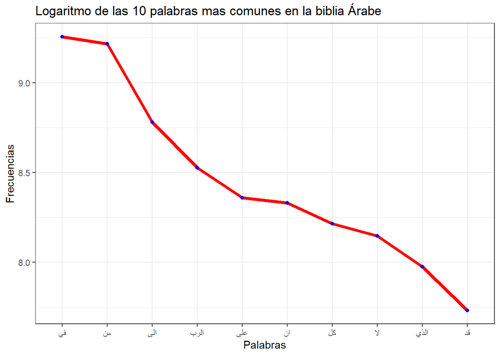

```r
### Proyectar el logaritmo de las palabras
ggplot(muestra,aes(x=reorder(Palabra,-Totales),
                   y = log(Totales) ,
                   group=1)) +
  geom_line(col = "red",
            lwd = 1.5)+
  geom_point(col = "blue",
             pch = 16)+
  theme_bw() +
  labs(x = "Palabras",
       y = "Frecuencias" ) +
  ggtitle("Logaritmo de las 10 palabras mas comunes en la biblia Árabe ")
```